# CPVA 2.0 User Guide

## 2.1. Introduction

Liquid chromatography-mass spectrometry (LC-MS)-based non-targeted metabolomics and chemical exposomics can qualitatively and quantitatively measure known and unknown chemical molecules in the internal and external environments of life. These chemical molecules are typically represented as features. Although features may represent all detected chemical molecules, most features are often unidentified in high-resolution mass spectrometry. Understanding this issue is crucial for the annotation and interpretation of metabolomics and chemical exposomics data, as well as for the future development of this field. To overcome this challenge, the software CPVA 2.0 was developed, empowering users to create interactive displays to support data exploration. These displays are easy to share and are not dependent on specific operating systems. CPVA 2.0 allows users to interactively optimize feature extraction parameters and evaluate the peak morphology confidence. It also enables users to assess the quality of each feature by starting from the raw mass spectrometry data, performing feature extraction, feature annotation and chromatographic peak evaluation.

Main modules: Tune, Features, and SmartChrom.

## 2.2. Getting Started

### 2.2.1 Overview of the Interface

CPVA 2.0 is a web-based Shiny application. A modern browser (Chrome, Edge, or Safari) is sufficient; no local installation of R is required for the standard online instance. The interface is organized into a single sidebar-driven layout.

Left sidebar menu provides the following primary navigation items:

- Home: Landing page with a concise description of the three main modules and direct entry buttons.
- Peaks Curation: The main analytical workflow, containing three modules:
- Tune: Interactive optimization of LC-MS peak-detection parameters.
- Features: End-to-end feature extraction, annotation, and project management.
- SmartChrom: Chromatographic peak quality assessment and filtering.
- Help: Links to documentation and citation information.

## 2.3. Module 1: Tune

### 2.3.1 Loading and Visualizing LC-MS Data

#### Loading Data Files

- Click the Select LC-MS data files button to open a file browser dialog .
- Select one or more mzML or mzXML files containing MS1-level spectra for processing (Datasets: MTBLS1785).
- Upon selection, the files will be loaded and displayed in the file list panel.

#### Data Visualization

Select any loaded file from the list to visualize its key chromatograms and spectra.

The interface will display:

- Total Ion Chromatogram (TIC): The summed intensity of all ions detected at each retention time.
- Base Peak Chromatogram (BPC): The intensity of the most abundant ion at each retention time.
- MS1 Spectra Browser: Interactive display of mass spectra for individual scans.

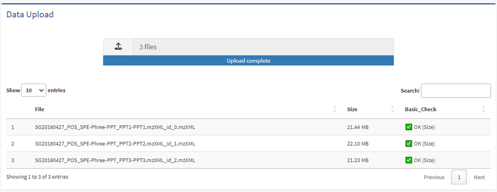

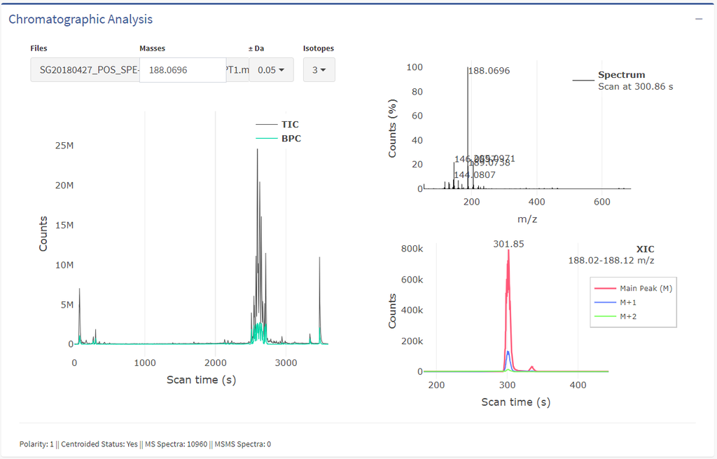

Base Peak Chromatogram (BPC) visualization

### 2.3.2 Optimizing Peak Detection Parameters

#### Experimental Setup

- Select an appropriate instrument platform. The software provides parameter references for different chromatography–mass spectrometry combinations, such as UPLC/UHPLC liquid chromatography, HILIC/C18 columns, and Orbitrap/TOF mass analyzers.
- The default retention-time range is 0–1000 minutes.
- Select the positive or negative ionization mode for the MS data; mixed-mode data extraction and analysis are not supported.

#### Running Initial Peak Detection

- Adjust the peak picking parameters in the left panel according to your analytical system and requirements.
- Click the Submit button to execute the XCMS-based peak detection algorithm with the specified parameters.
- The results, including extracted features and processing summaries, will appear in the Feature View tab.
- Click Save to export the current parameter set for future use or reproducibility.

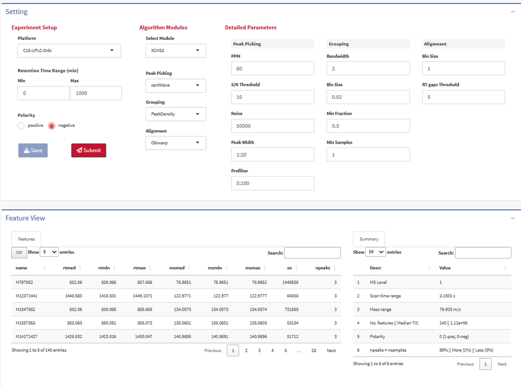

Feature View after initial peak detection

#### Visualizing Mass Traces and Chromatograms

To refine m/z tolerance and bandwidth parameters, specify a target m/z and retention time range.

Click Submit to generate visualizations that aid in parameter optimization:

- Mass Traces Plot: Shows extracted ion chromatograms for the specified m/z window, helping assess m/z alignment.
- Feature Chromatograms: Displays individual peak shapes for quality assessment.
- Peak Density Plot: Visualizes peak distribution across the retention time axis, informing bandwidth selection.

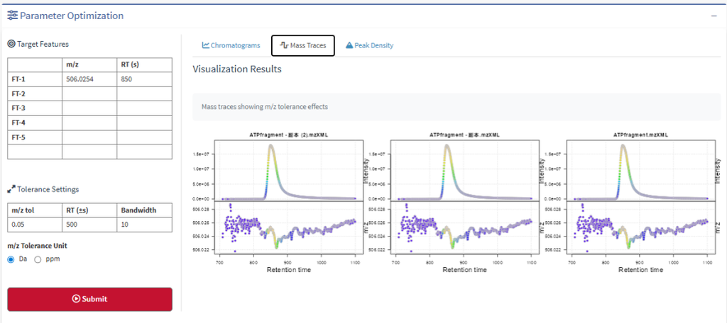

The mass traces plot

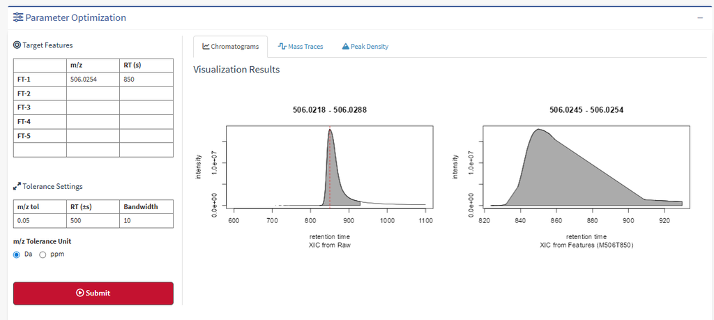

The feature chromatograms

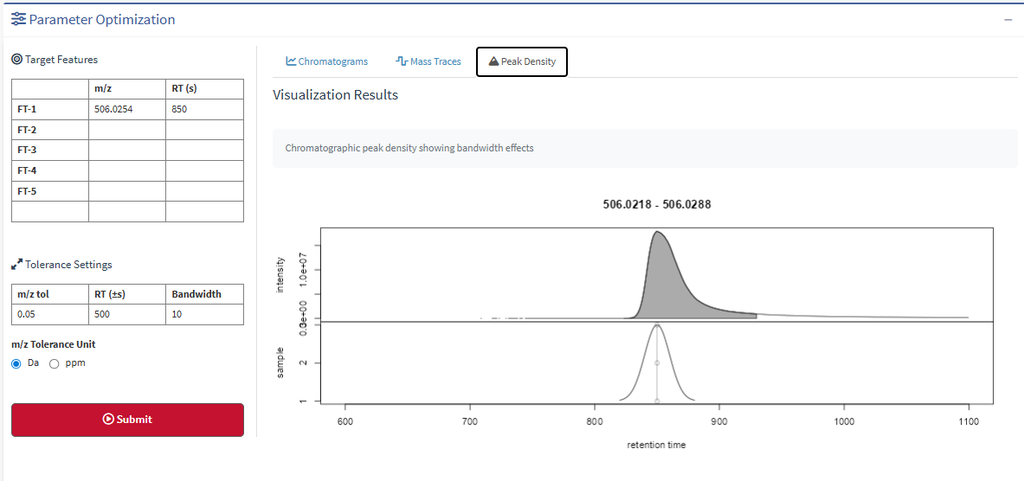

The peak density

### 2.3.3 Parameter Reference

#### Peak Detection (centWave Algorithm)

This algorithm is optimized for high-resolution LC-MS data. Key parameters include:

- ppm: Maximum tolerated m/z deviation, expressed in parts per million (ppm). Defines the width of the m/z window for chromatographic peak detection.
- peakwidth: Expected chromatographic peak width range (minimum, maximum) in seconds. Should be estimated from representative chromatograms.
- snthresh: Signal-to-noise ratio threshold. Peaks with lower signal-to-noise ratios are filtered out.
- prefilter: Criteria for retaining mass traces during Region of Interest (ROI) detection. Requires at least k data points with intensity ≥ I.
- noise: Absolute intensity threshold. Data points below this value are excluded from initial processing steps.
- mzdiff: Minimum m/z difference required to distinguish co-eluting peaks. Can be set to negative values to allow peak overlap.

#### Peak Grouping (Peak Density Algorithm)

Parameters controlling the alignment of peaks across samples:

- bw (bandwidth): bandwidth (standard deviation or half width at half maximum) of gaussian smoothing kernel to apply to the peak density chromatogram.
- minFrac: Minimum fraction of samples where a peak must be detected for it to be retained as a feature.
- minsamp: Minimum absolute number of samples where a peak must be detected.
- binSize: Size (in m/z units) of the bins used for grouping peaks across samples during the alignment step.

## 2.4. Module 2: Features

### 2.4.1 Data Import and Processing Setup

#### Loading Data for Feature Extraction

Click Select MS data files to import mzML/mzXML files for comprehensive feature analysis (Datasets: MTBLS146).

For studies with targeted compounds or regions of interest, use the Hybrid peak extraction option by specifying:

- Precursor m/z value(s)
- Retention time window (in seconds)

#### Processing Data-Dependent Acquisition (DDA) Data

For experiments acquired in DDA mode, select the DDA processing option.

CPVA will correlate MS1 features with their corresponding MS/MS spectra.

Features are annotated regarding in-source fragmentation: The candidate coelutes with a precursor feature within a user-defined retention-time window, and the Pearson correlation of their MS1 extracted-ion chromatogram (EIC) traces is ≥ 0.80 (user-adjustable);

- L1 Annotation: Candidate coelutes with precursor, m/z matches precursor DDA MS², and candidate has its own DDA MS² with cosine similarity >0.60 vs precursor consensus spectrum..
- L2 Annotation: Candidate meets coelution and m/z criteria but lacks its own DDA MS² or has cosine similarity ≤0.60.

### 2.4.2 Configuring Processing Parameters

- Click the Parameters button to load a previously saved parameter file (e.g., from the Tune module).
- For large datasets, enable Parallel processing to distribute computational load across multiple CPU cores and reduce processing time.
- Click Start analysis to initiate the comprehensive feature extraction workflow.

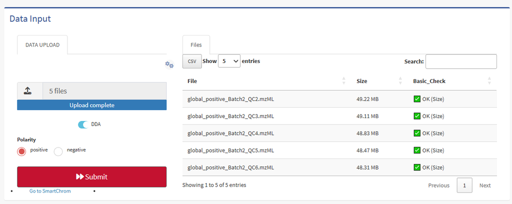

Feature extraction workflow configuration

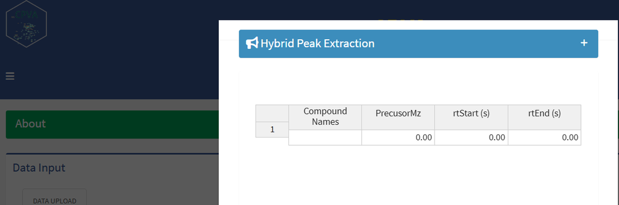

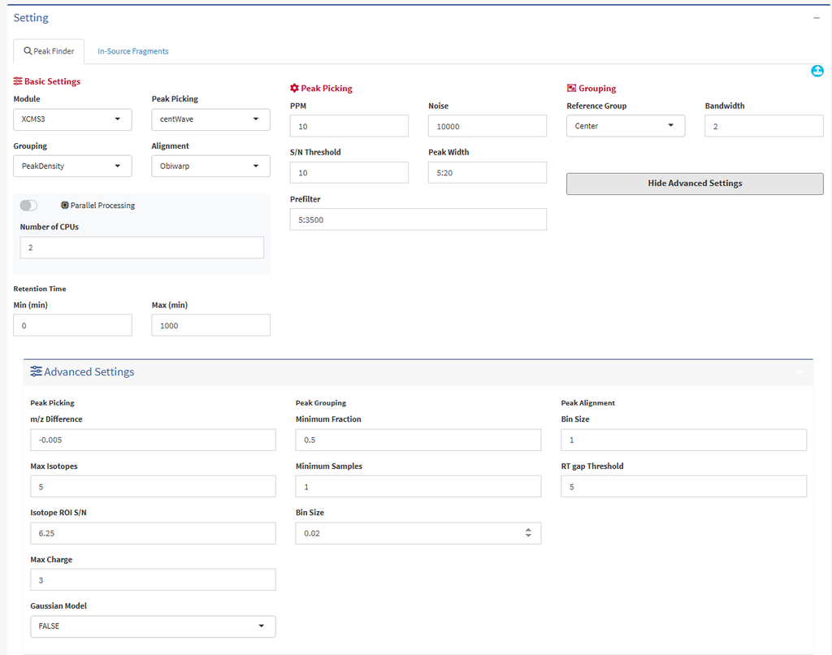

### 2.4.3 Feature Extraction and Review

#### Reviewing Processing Results

After analysis completion, the interface presents multiple tabs for result exploration:

- Feature Table: A comprehensive list of all detected features with annotations.
- Visualizations: Multiple plots for quality assessment.

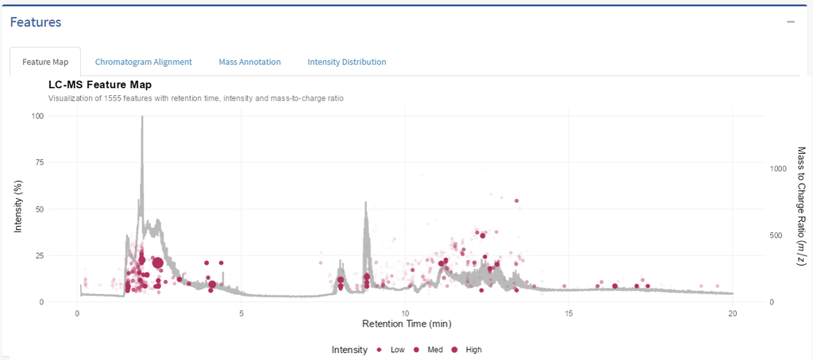

Global overview of chromatographic peaks

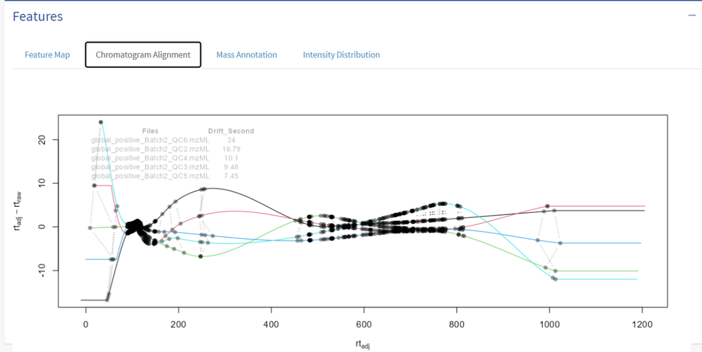

The difference between the adjusted and raw retention times

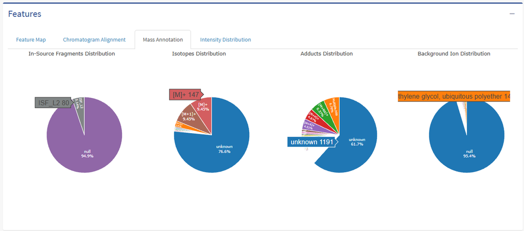

Annotation of ISF, adducts, isotopes and background contaminants

#### Mass Annotation (ISF / Isotope / Adduct / Background Contaminant)

After the comprehensive feature extraction pipeline finishes, CPVA automatically annotates every detected feature with four orthogonal label classes. The results are summarized in four interactive pie charts under the “Mass Annotation” tab:

- isfPieplot: Distribution of in-source fragmentation ions among features.
- isotopePieplot: Distribution of isotopic peaks ([M+1], [M+2], …).
- adducPieplot: Distribution of adducts ([M+H]+, [M+Na]+, [M+K]+, [M+NH4]+, …).
- contaPieplot: Distribution of background contaminant ions.

These four pie charts give an instant global assessment of annotation coverage and help identify whether a dataset is contaminated or dominated by adducts rather than protonated molecules.

#### Fragment Detection Parameters (DDA mode)

When DDA (data-dependent acquisition) is enabled, CPVA correlates each MS1 feature with its matching MS/MS spectrum and performs fragment-ion annotation. Tune the following parameters to control fragment detection:

- m/z Tolerance (± Da): Allowed m/z deviation when matching fragment ions (default 0.02).
- RT Tolerance (± Sec): Allowed retention-time deviation (default 30 s).
- Noise Threshold (MS2): Minimum absolute MS2 intensity retained (default 100).
- Relative Noise (%): Minimum relative intensity threshold for fragment peaks.
- Co-expression Score: Minimum Pearson correlation between MS1 and MS2 chromatograms (default 0.8).
- MS2 Similarity Score: Minimum cosine similarity between MS2 spectrum of the precursor and fragments (default 0.6).

The feature table provides comprehensive information for each detected analyte:

- name: Feature name
- rtmed: Median retention time.
- mzmed: Median m/z value.
- fragCount: Number of fragment ions in MS2 spectrum of this feature.
- ISFrag: Ion-source fragments (See 2.4.1).
- isotopes: The isotope peaks are denoted as [M + 1], [M + 2], … ions. [M + 1] is the first isotopic peak for the monoisotopic peak [M].
- adduct: Adducts are generally observed in ESI-MS data. The protonated molecular ion ([M+H]+) is accompanied by kinds of adduct formation, such as [M + Na]+, [M + K]+, [M + NH4]+, etc.
- backgroundIon: Background ions are frequently observed in MS background. Common MS background ions were curated from repeated solvent and procedural blank analyses as the backgroundIon database (Keller et al. 2008); features matched to the database are flagged rather than automatically removed.

#### Managing the Feature Table

- Edit feature names or notes directly in the table.
- Click Save to commit all changes to the project file.

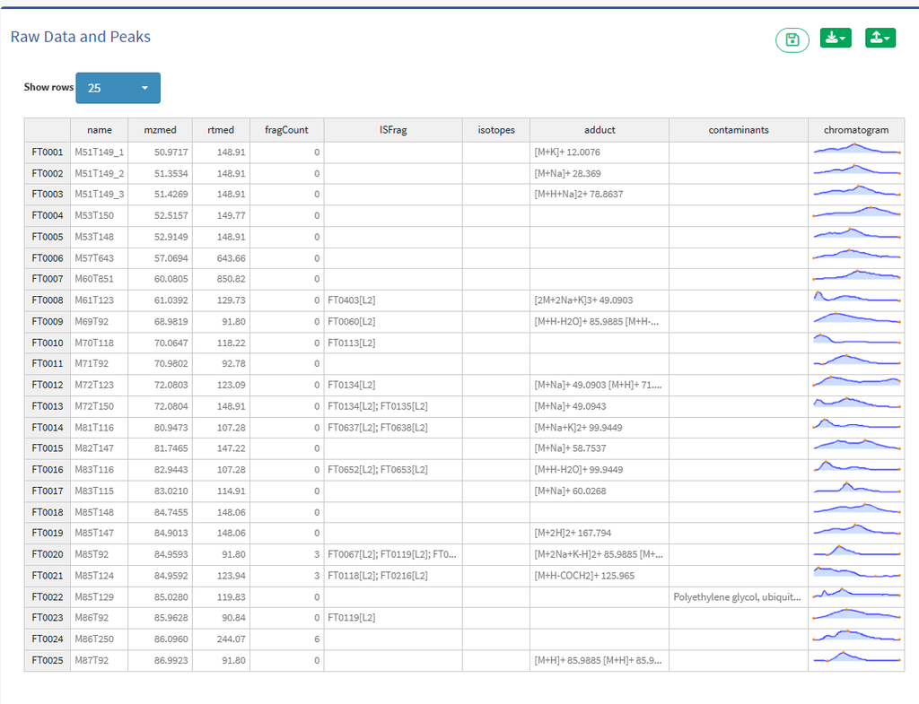

Editable feature table with annotations

### 2.4.4 Data Export and Project Management

#### Exporting Results

Click Download to export:

- Complete feature table (CSV format)
- Annotated MS/MS spectra (if available)

#### Saving and Loading Projects (offline version)

- CPVA automatically creates a .cpva project file containing all processed data and annotations.
- Click Upload to resume work on a previously saved project.
- Project files maintain complete processing history and user annotations.

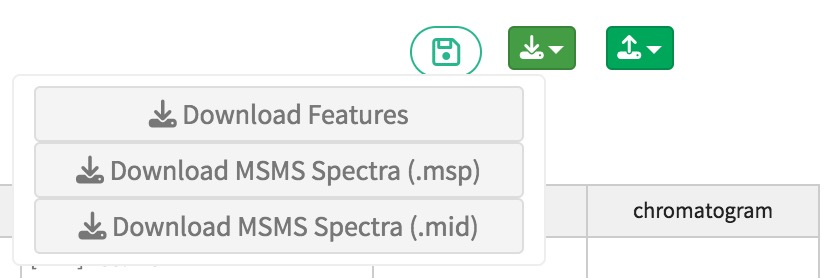

## 2.5. Module 3: SmartChrom

### 2.5.1 Assessing Chromatographic Quality

SmartChrom provides automated assessment of chromatographic peak quality using multiple orthogonal metrics. The module assigns quality scores and visual indicators:

- Blue Indicators: High-confidence peaks with optimal chromatographic properties.
- Red Indicators: Low-confidence peaks requiring further inspection or potential exclusion.

### 2.5.2 Chromatographic Quality Metrics

SmartChrom calculates eighteen shape, noise, and modality descriptors. All eighteen metrics are available in the Metrics dropdown and can be plotted via the Metric Distribution panel. For more information on these metrics, please refer to the original publications (Kumler et al. 2023, Eshghi et al. 2018, Zhang and Zhao 2014, and Chetnik et al. 2020).

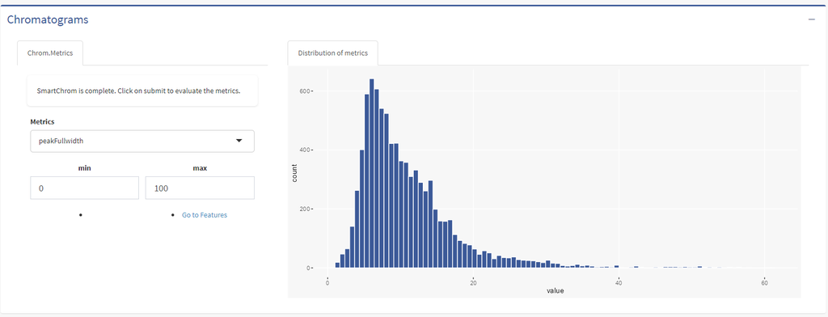

Metric Distribution histogram

### 2.5.3 Threshold Calibration (TLV and Weighted Pass Fraction)

SmartChrom ships with default TLV (Threshold Limit Values) for eight core metrics. Each slider defines a per-metric cutoff that a peak must satisfy to be classified as high-confidence (blue). You may tune these thresholds interactively or let the application calibrate them automatically from a labeled reference set.

Per-metric TLV sliders (under the TLV panel):

- Beta_cor: Minimum Pearson correlation to a fitted beta distribution (default ≥ 0.4).
- Beta_snr: Minimum signal-to-noise ratio from beta residuals (default ≥ 4).
- MCQ-Index: Minimum composite chromatographic quality index (default ≥ 0.3).
- GaussianSimilarity: Minimum dot-product similarity to an ideal Gaussian (default ≥ 0.4).
- ZigZag-Index: Maximum allowed zigzag noise in the apex region (default ≤ 0.9).
- Sharpness: Minimum sharpness index (default ≥ 2).
- Apex/Boundary: Minimum apex-to-boundary intensity ratio; values below this indicate shoulder/co-elution (default ≥ 3).
- Max Intensity (k): Absolute apex-intensity floor, in thousands of cps (default ≥ 1 k).

Two complementary controls refine how thresholds are applied:

- Weighted pass fraction: Share of metrics that must pass. Default 1.0 = strict AND logic; lower values (e.g., 0.6) let a reliable metric compensate for a weaker one.
- Calibrate from Labels: Clicking this purple button automatically re-calibrates every TLV using features that the user has previously labeled as reliable or poor. After adjusting sliders, click the red Submit button to re-score all features. Blue peaks satisfy all weighted thresholds; red peaks fail one or more. The Metric Distribution histogram provides immediate visual feedback on the chosen thresholds.

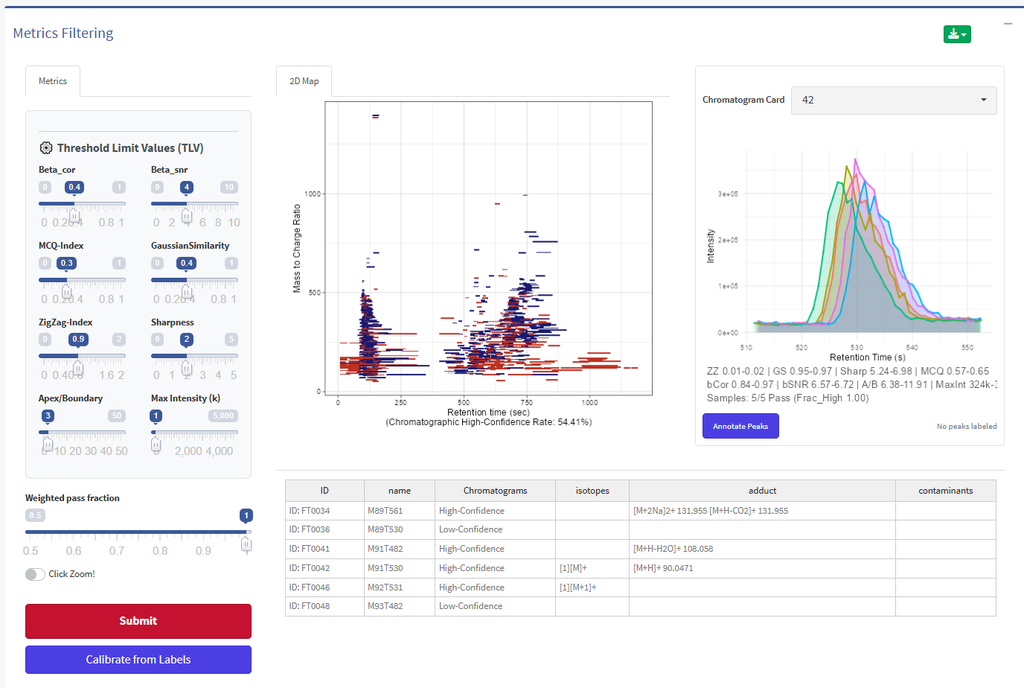

Threshold Limit Values (TLV) slider group and Calibrate from Labels button

### 2.5.4 Manual Peak Annotation & Threshold Tuning

The Annotate Peaks workspace supports manual review of chromatographic peak quality and data-driven threshold tuning. In this section, annotation refers to user-assigned high-quality (H) and low-quality (L) peak labels.

#### Opening the Annotation Workspace

Click the purple Annotate Peaks button below the Chromatogram Card to open the Manual Peak Annotation & Threshold Tuning dialog. The dialog contains two tabs: Annotate for peak inspection and manual labeling, and Thresholds for performance evaluation and threshold adjustment.

- Annotation unit: One feature–sample peak, rather than an entire feature across all samples.
- Annotate tab: Select peaks, assign H/L labels, inspect chromatograms and metrics, and download chromatographic data.
- Thresholds tab: Evaluate labeled-set performance, adjust metric thresholds, and snap thresholds to a target false-negative rate.

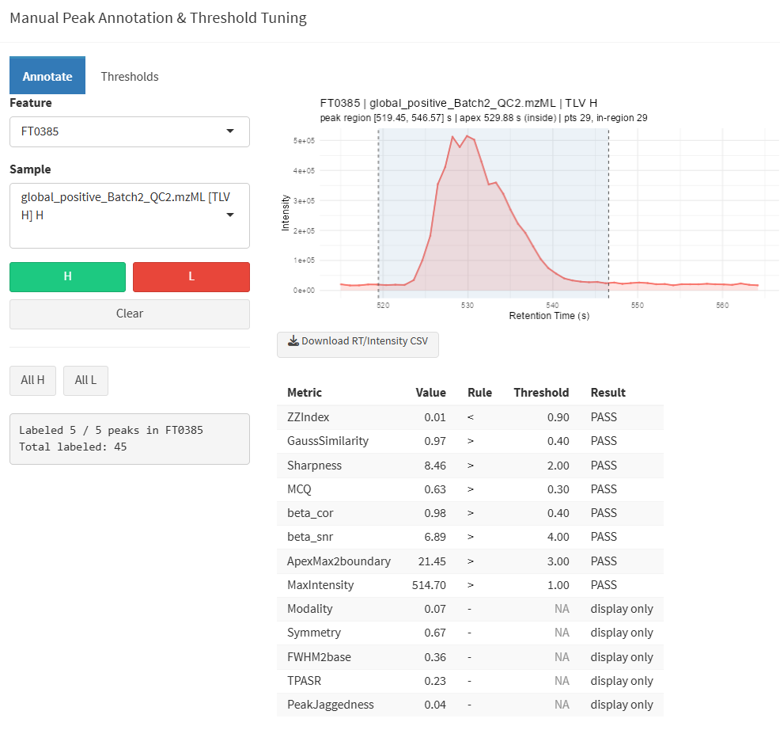

Manual Peak Annotation & Threshold Tuning — Annotate tab

#### Assigning Manual H/L Labels

Use the Feature and Sample selectors to choose the peak to review. The Sample selector also displays the current TLV classification and any existing manual label. Assign labels only after inspecting the chromatogram and its quality metrics.

- H: Marks the selected feature–sample peak as high quality.
- L: Marks the selected feature–sample peak as low quality.
- Clear: Removes the manual label from the selected peak.
- All H / All L: Assigns the selected label to all eligible sample peaks of the current feature. Empty peaks are excluded.

Peaks without sufficient valid scans in the peak region do not provide reliable shape information and are excluded from subsequent calibration.

#### Reviewing the Selected Peak

The annotation plot displays the extracted ion chromatogram for the selected feature and sample. The integrated peak region is highlighted with shading and dashed boundary lines. Review the peak boundaries, apex position, number of valid scans, and overall peak shape before assigning a label.

- ND — no chrompeak: No chromatographic peak was detected for the feature in this sample; only the EIC is available.
- ND — empty peak region: A peak region exists, but fewer than four valid scans are available for shape evaluation.
- Metric table: Reports each metric value, comparison rule, active threshold, and PASS/FAIL result. Display-only metrics are marked accordingly.
- Download RT/Intensity CSV: Exports sampleID, rtime, intensity, peak-region boundaries (rtmin and rtmax), and the in_peak indicator for the selected chromatogram.

#### Interactive Threshold Tuning

Switch to the Thresholds tab to adjust thresholds against the manually labeled peaks. When the dialog opens, its threshold controls inherit the current values from the main SmartChrom interface. Subsequent slider changes affect the active thresholds inside the dialog.

- Threshold metrics used in the H/L decision: ZZIndex, GaussSimilarity, Sharpness, MCQ, beta_cor, beta_snr, ApexMax2boundary, and MaxIntensity.
- Display-only metrics: Modality, Symmetry, FWHM2base, TPASR, and PeakJaggedness. These metrics support visual diagnosis but do not participate in the H/L decision.
- Direction legend: An upward arrow indicates that larger values are better; a downward arrow indicates that smaller values are better.

#### Evaluating Labeled-Set Performance

The Labeled-set performance table compares the current threshold-based classifications with the manual H/L labels. Use it together with sensitivity and specificity to determine whether the current rule retains high-quality peaks while rejecting low-quality peaks.

- H/L distributions: H peaks are shown in green and L peaks in red.
- H/L AUC: Measures how well a metric separates H from L peaks. A value near 0.5 indicates substantial overlap; a value near 1.0 indicates strong separation. Metrics are ordered by H/L AUC.
- Current-threshold Sens/Spec: For thresholded metrics, reports the single-metric sensitivity and specificity at the active threshold.
- Display-only distributions: Show H/L separation without a threshold slider or a direct contribution to the final decision.

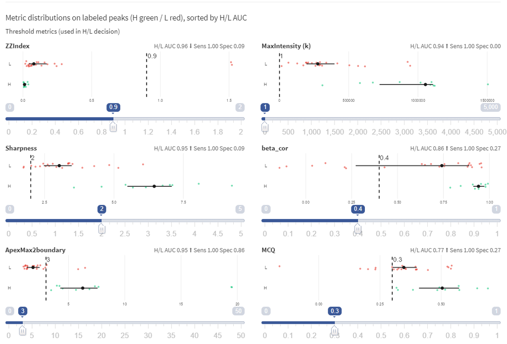

H/L metric distributions and interactive threshold sliders

#### Snapping Thresholds to a Target FNR

The Max % of true-H peaks allowed to be rejected control defines the acceptable false-negative rate (FNR). Click Snap thresholds to target FNR to search for strict thresholds while keeping the proportion of manually labeled H peaks classified as L at or below the selected target.

- Target range: 0–50%, with a default of 20%.
- Lower FNR: Prioritizes retention of manually confirmed high-quality peaks and reduces erroneous rejection.
- Higher FNR: Permits stricter filtering but may reject more true-H peaks.
- Minimum labeled set: At least 30 eligible labeled peaks containing both H and L classes are required.
- Snap report: Compares Prior, Data, and Applied thresholds and identifies metrics as tuned or defaults. Cross-validation determines whether the calibrated rule is adopted or the default rule is retained.

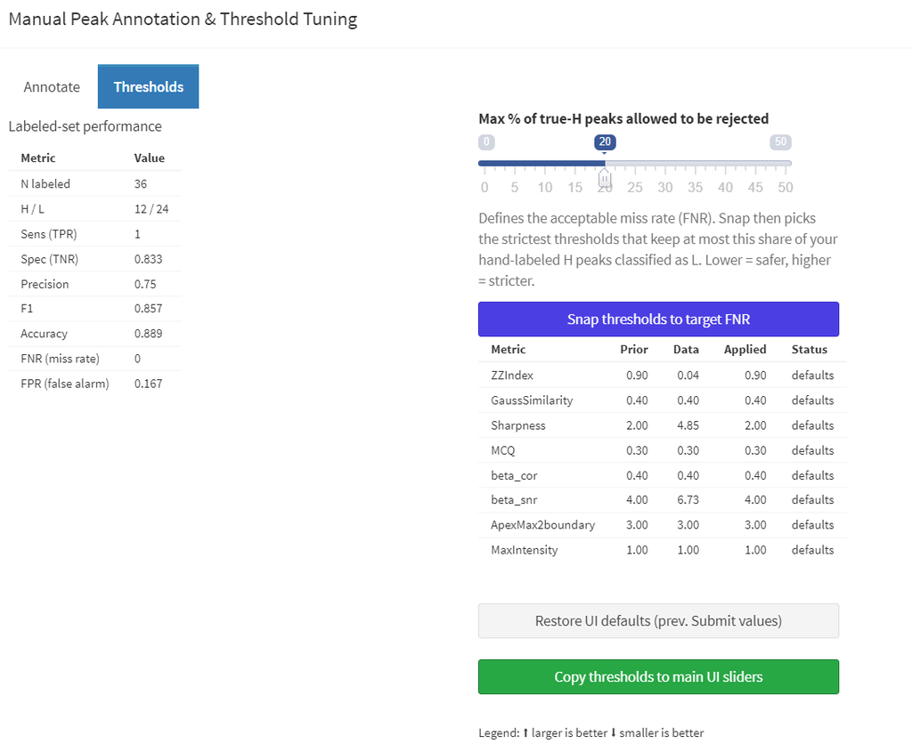

Thresholds tab — labeled-set performance and target-FNR controls

#### Applying or Restoring Thresholds

Threshold adjustments inside the dialog do not by themselves regenerate the main SmartChrom filtering results. Use the following controls to restore or apply the settings.

- Restore UI defaults (prev. Submit values): Restores the dialog thresholds from the current main-interface slider values.
- Copy thresholds to main UI sliders: Transfers the active dialog thresholds to the main TLV sliders.
- Submit: After copying the thresholds and closing the dialog, click Submit in the main interface to re-evaluate all peaks.
- Calibrate from Labels: Provides the corresponding calibration workflow directly from the main Metrics Filtering panel. Review its report and the Weighted pass fraction before submitting.

#### Recommended Annotation–Calibration Workflow

The following workflow links manual review, threshold tuning, and final peak filtering:

- Select representative features and samples for manual review.
- Inspect chromatograms and metric results, then assign sufficient H and L labels.
- Open the Thresholds tab and review AUC, metric distributions, sensitivity, and specificity.
- Set the target FNR and click Snap thresholds to target FNR.
- Review the calibration report and manually refine thresholds if necessary.
- Click Copy thresholds to main UI sliders and inspect the Weighted pass fraction.
- Close the dialog and click Submit to apply the final filtering rule.
- Review the resulting H/L/ND classifications and download the filtered results.

### 2.5.5 Interactive 2D Map and Brushing

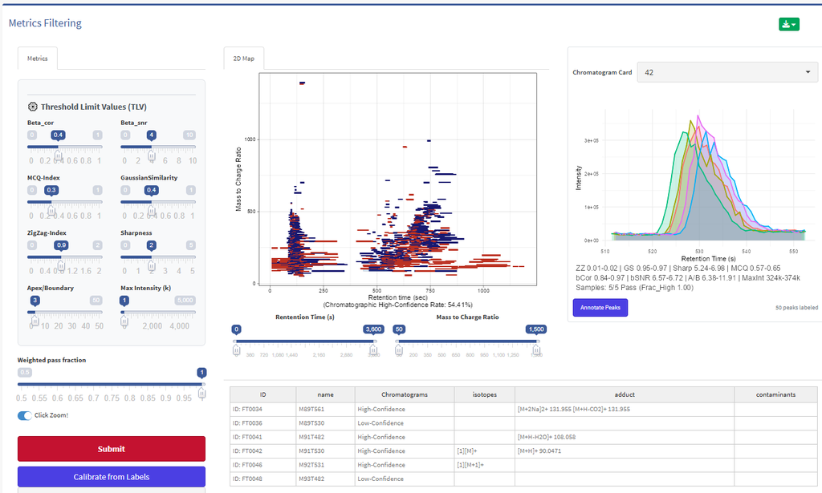

### 2.5.6 Filtering and Exporting

- Review the quality scores assigned to each feature.
- Use the interactive plots to identify features with poor chromatographic characteristics.
- Filter features based on quality thresholds for downstream statistical analysis.
- Click Save to export the quality-annotated feature table.

## 2.6. Expected Outputs

### 2.6.1 Exported Files

- **Features_positive_*.csv**: Comprehensive feature table with m/z, RT, area, and annotations.
- **FeatureMetrics_*.csv**: Per-feature chromatographic quality metrics (18 columns).
- **FeatureQuality_*.csv**: Final blue/red classification after TLV scoring.